# Exercise2 : Coordinate Reference Systems

Python

Code

Geopandas

Author

Jinwon Lee

Published

April 29, 2023

> Kaggle Geospatial Analysis Exercise 2

**이 노트북은 Kaggle [Geospatial Analysis](https://www.kaggle.com/learn/geospatial-analysis)의 Exercise 입니다. 이 [링크](https://jw0112.github.io/blog/Data_Mining/Geospatial_Analysis/Geospatial_Analysis#lesson-2-coordinate-reference-systems)로 튜토리얼을 볼 수 있습니다.**

# 소개

당신은 조류 보호 전문가이며 보라색 담비의 이동 패턴을 이해하고자 합니다. 연구를 통해 이 새가 일반적으로 미국 동부에서 여름 번식기를 보낸 후 겨울을 위해 남미로 이동한다는 사실을 알게 되었습니다. 하지만 이 새는 멸종 위기에 처해 있기 때문에 이 새가 방문할 가능성이 높은 장소를 자세히 살펴보고 싶을 것입니다.

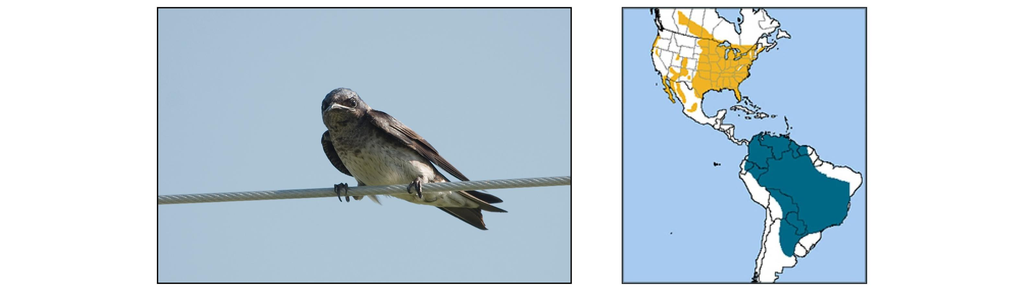

남아메리카에는 여러 [보호 지역](https://www.iucn.org/theme/protected-areas/about)이 있으며, 이 지역으로 이동하거나 서식하는 종들이 번성할 수 있는 최상의 기회를 갖도록 특별 규정에 따라 운영되고 있습니다. 보라색 담비가 이러한 지역을 방문하는 경향이 있는지 알고 싶을 것입니다. 이 질문에 답하기 위해 최근에 수집한 11가지 새의 연중 위치를 추적하는 데이터를 사용합니다.

```python
import warnings
warnings.filterwarnings(action = 'ignore')

import pandas as pd
import geopandas as gpd

from shapely.geometry import LineString
```

### 1) 데이터 불러오기

다음 셀을 실행하여 GPS 데이터를 `birds_df` DataFrame 에 로드합니다.

```python
birds_df = pd.read_csv('./geospatial-learn-course-data/purple_martin.csv', parse_dates = ['timestamp'])
print(f"There are {birds_df['tag-local-identifier'].nunique()} different birds in the dataset.")
birds_df.head()
```

```
There are 11 different birds in the dataset.
```

|  | timestamp | location-long | location-lat | tag-local-identifier |
| --- | --- | --- | --- | --- |
| 0 | 2014-08-15 05:56:00 | -88.146014 | 17.513049 | 30448 |
| 1 | 2014-09-01 05:59:00 | -85.243501 | 13.095782 | 30448 |
| 2 | 2014-10-30 23:58:00 | -62.906089 | -7.852436 | 30448 |
| 3 | 2014-11-15 04:59:00 | -61.776826 | -11.723898 | 30448 |
| 4 | 2014-11-30 09:59:00 | -61.241538 | -11.612237 | 30448 |

`bird_df` 데이터셋에는 11마리의 새가 있으며, 각 새는 `tag-local-identifier` 열의 고유 값으로 식별됩니다. 각 새는 일 년 중 다른 시기에 수집된 여러 측정값을 가지고 있습니다.

다음 셀을 사용하여 GeoDataFrame `birds`를 만듭니다.  
- `birds`에는 (경도, 위도) 위치가 있는 포인트 개체를 포함하는 `geometry` 열과 함께 `birds_df`의 모든 열이 있어야 합니다.  
- `birds`의 CRS를 `{'init': 'epsg:4326'}`로 설정합니다.

```python
birds = gpd.GeoDataFrame(birds_df, geometry = gpd.points_from_xy(birds_df['location-long'], birds_df['location-lat']))
birds.crs = {'init': 'epsg:4326'}
birds.head()
```

|  | timestamp | location-long | location-lat | tag-local-identifier | geometry |
| --- | --- | --- | --- | --- | --- |
| 0 | 2014-08-15 05:56:00 | -88.146014 | 17.513049 | 30448 | POINT (-88.14601 17.51305) |
| 1 | 2014-09-01 05:59:00 | -85.243501 | 13.095782 | 30448 | POINT (-85.24350 13.09578) |
| 2 | 2014-10-30 23:58:00 | -62.906089 | -7.852436 | 30448 | POINT (-62.90609 -7.85244) |
| 3 | 2014-11-15 04:59:00 | -61.776826 | -11.723898 | 30448 | POINT (-61.77683 -11.72390) |
| 4 | 2014-11-30 09:59:00 | -61.241538 | -11.612237 | 30448 | POINT (-61.24154 -11.61224) |

### 2) 데이터 시각화

다음 셀을 실행하여 GeoPandas에서 `'naturalearth_lowres'` 데이터를 로드하고 아메리카 대륙(북미와 남미 모두)의 모든 국가의 경계를 포함하는 GeoDataFrame을 `americas`로 설정합니다.

```python
world = gpd.read_file(gpd.datasets.get_path('naturalearth_lowres'))
americas = world.loc[world['continent'].isin(['North America', 'South America'])]
americas.head()
```

|  | pop_est | continent | name | iso_a3 | gdp_md_est | geometry |
| --- | --- | --- | --- | --- | --- | --- |
| 3 | 37589262.0 | North America | Canada | CAN | 1736425 | MULTIPOLYGON (((-122.84000 49.00000, -122.9742... |
| 4 | 328239523.0 | North America | United States of America | USA | 21433226 | MULTIPOLYGON (((-122.84000 49.00000, -120.0000... |
| 9 | 44938712.0 | South America | Argentina | ARG | 445445 | MULTIPOLYGON (((-68.63401 -52.63637, -68.25000... |
| 10 | 18952038.0 | South America | Chile | CHL | 282318 | MULTIPOLYGON (((-68.63401 -52.63637, -68.63335... |
| 16 | 11263077.0 | North America | Haiti | HTI | 14332 | POLYGON ((-71.71236 19.71446, -71.62487 19.169... |

다음 셀을 사용하여 (1) `Americas` GeoDataFrame의 국가 경계와 (2) `birds_gdf` GeoDataFrame의 모든 점을 모두 표시하는 단일 플롯을 만듭니다.

여기서 특별한 스타일링에 대해 걱정할 필요 없이 모든 데이터가 제대로 로드되었는지 간단히 확인하기 위해 예비 플롯을 만들면 됩니다. 특히, 새를 구분하기 위해 점을 색상으로 구분할 필요가 없으며, 시작점과 끝점을 구분할 필요도 없습니다. 이 작업은 다음 Exercise에서 하도록 하겠습니다.

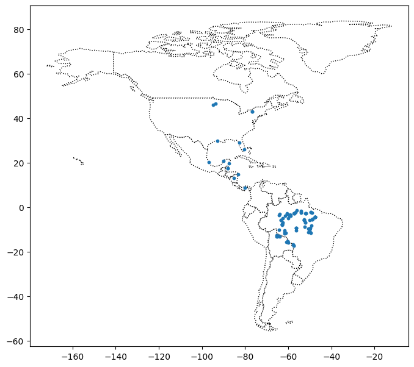

```python
ax = americas.plot(figsize = (8, 8), color = 'white', linestyle = ':', edgecolor = 'black')
birds.plot(ax = ax, markersize = 10)
```

### 3) 각 새들의 여행의 출발지와 도착지는 어디인가요? (파트 1)

이제 각 새의 경로를 더 자세히 살펴볼 준비가 되었습니다. 다음 셀을 실행하여 두 개의 GeoDataFrame을 만듭니다. - `path_gdf`에는 각 새의 경로를 표시하는 LineString 객체가 포함되어 있습니다. 이 셀은 `LineString()` 메서드를 사용하여 Point 개체 목록에서 LineString 개체를 만듭니다. - `start_gdf`에는 각 새의 경로의 시작 지점이 포함됩니다.

```python
path_df = birds.groupby('tag-local-identifier')['geometry'].apply(list).apply(lambda x : LineString(x)).reset_index()
path_gdf = gpd.GeoDataFrame(path_df, geometry = path_df.geometry)
path_gdf.crs = {'init' :'epsg:4326'}

start_df = birds.groupby('tag-local-identifier')['geometry'].apply(list).apply(lambda x : x[0]).reset_index()
start_gdf = gpd.GeoDataFrame(start_df, geometry = start_df.geometry)
start_gdf.crs = {'init' :'epsg:4326'}

start_gdf.head()
```

|  | tag-local-identifier | geometry |
| --- | --- | --- |
| 0 | 30048 | POINT (-90.12992 20.73242) |
| 1 | 30054 | POINT (-93.60861 46.50563) |
| 2 | 30198 | POINT (-80.31036 25.92545) |
| 3 | 30263 | POINT (-76.78146 42.99209) |
| 4 | 30275 | POINT (-76.78213 42.99207) |

다음 셀을 사용하여 각 새의 최종 위치가 포함된 `end_gdf` GeoDataFrame을 만듭니다.  
- 형식은 두 개의 열(`tag-local-identifier` 및 `geometry`)이 있는 `start_gdf`와 동일해야 하며, 여기서 `geometry` 열에는 포인트 개체가 포함되어야 합니다. - `end_gdf`의 CRS를 `{'init': 'epsg:4326'}`로 설정합니다.

```python
end_df = birds.groupby('tag-local-identifier')['geometry'].apply(list).apply(lambda x : x[-1]).reset_index()
end_gdf = gpd.GeoDataFrame(end_df, geometry = end_df.geometry)
end_gdf.crs = {'init' :'epsg:4326'}

end_gdf.head()
```

|  | tag-local-identifier | geometry |
| --- | --- | --- |
| 0 | 30048 | POINT (-47.53632 -4.43758) |
| 1 | 30054 | POINT (-62.47914 -5.03840) |
| 2 | 30198 | POINT (-57.46417 -2.77617) |
| 3 | 30263 | POINT (-50.19230 -5.70504) |
| 4 | 30275 | POINT (-57.70404 -16.72336) |

### 4) 각 새들의 여행의 출발지와 도착지는 어디인가요? (파트 2)

위의 GeoDataFrame(`path_gdf`, `start_gdf`, `end_gdf`)을 사용하여 모든 새의 경로를 단일 맵에 시각화합니다. `americas` GeoDataFrame을 사용할 수도 있습니다.

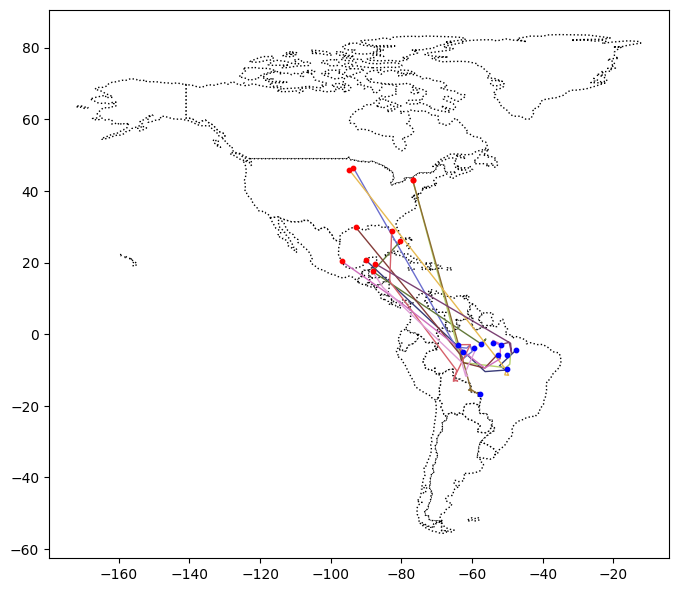

```python
ax = americas.plot(figsize = (8, 8), color = 'white', linestyle = ':', edgecolor = 'black')
path_gdf.plot(ax = ax, cmap = 'tab20b', linewidth = 1, linestyle = '-', zorder = 1)
start_gdf.plot(ax = ax, color = 'red', markersize = 10)
end_gdf.plot(ax = ax, color = 'blue', markersize = 10)
```

### 5) 남아메리카의 보호 지역은 어디인가요? (파트 1)

모든 새들은 남미 어딘가에 있는 것 같습니다. 하지만 새들이 보호 지역으로 갈까요?

다음 셀에서는 남아메리카의 모든 보호 지역의 위치가 포함된 `protected_areas` GeoDataFrame을 만듭니다. 해당 shapefile은 파일 경로 `protected_filepath`에 있습니다.

```python
protected_filepath = './geospatial-learn-course-data/SAPA_Aug2019-shapefile/SAPA_Aug2019-shapefile/SAPA_Aug2019-shapefile-polygons.shp'
protected_areas = gpd.read_file(protected_filepath)
protected_areas.head()
```

|  | WDPAID | WDPA_PID | PA_DEF | NAME | ORIG_NAME | DESIG | DESIG_ENG | DESIG_TYPE | IUCN_CAT | INT_CRIT | ... | GOV_TYPE | OWN_TYPE | MANG_AUTH | MANG_PLAN | VERIF | METADATAID | SUB_LOC | PARENT_ISO | ISO3 | geometry |
| --- | --- | --- | --- | --- | --- | --- | --- | --- | --- | --- | --- | --- | --- | --- | --- | --- | --- | --- | --- | --- | --- |
| 0 | 14067.0 | 14067 | 1 | Het Spaans Lagoen | Het Spaans Lagoen | Ramsar Site, Wetland of International Importance | Ramsar Site, Wetland of International Importance | International | Not Reported | Not Reported | ... | Not Reported | Not Reported | Not Reported | Management plan is not implemented and not ava... | State Verified | 1856 | Not Reported | NLD | ABW | POLYGON ((-69.97523 12.47379, -69.97523 12.473... |
| 1 | 14003.0 | 14003 | 1 | Bubali Pond Bird Sanctuary | Bubali Pond Bird Sanctuary | Bird Sanctuary | Bird Sanctuary | National | Not Reported | Not Applicable | ... | Not Reported | Not Reported | Not Reported | Not Reported | State Verified | 1899 | Not Reported | NLD | ABW | POLYGON ((-70.04734 12.56329, -70.04615 12.563... |
| 2 | 555624439.0 | 555624439 | 1 | Arikok National Park | Arikok National Park | National Park | National Park | National | Not Reported | Not Applicable | ... | Non-profit organisations | Non-profit organisations | Fundacion Parke Nacional Arikok | Not Reported | State Verified | 1899 | Not Reported | NLD | ABW | MULTIPOLYGON (((-69.96302 12.48384, -69.96295 ... |
| 3 | 303894.0 | 303894 | 1 | Madidi | Madidi | Area Natural de Manejo Integrado | Natural Integrated Management Area | National | Not Reported | Not Applicable | ... | Federal or national ministry or agency | Not Reported | Not Reported | Not Reported | State Verified | 1860 | BO-L | BOL | BOL | POLYGON ((-68.59060 -14.43388, -68.59062 -14.4... |
| 4 | 303893.0 | 303893 | 1 | Apolobamba | Apolobamba | Area Natural de Manejo Integado Nacional | National Natural Integrated Management Area | National | Not Reported | Not Applicable | ... | Federal or national ministry or agency | Not Reported | Not Reported | Not Reported | State Verified | 1860 | BO-L | BOL | BOL | POLYGON ((-69.20949 -14.73334, -69.20130 -14.7... |

5 rows × 29 columns

### 6) 남아메리카의 보호 지역은 어디인가요? (파트 2)

`protected_areas` GeoDataFrame을 사용하여 남아메리카의 보호 지역 위치를 표시하는 지도를 생성합니다. (일부 보호 지역은 육지에 있는 반면 다른 보호 지역은 해역에 있음을 알 수 있습니다.)

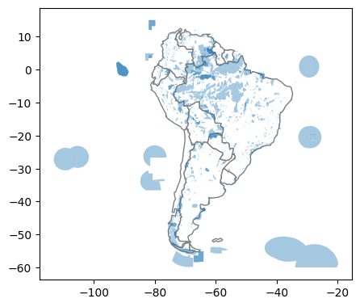

```python
south_america = americas.loc[americas['continent'] == 'South America']

ax = south_america.plot(figsize = (5, 5), color = 'white', edgecolor = 'gray')
protected_areas.plot(ax = ax, alpha = 0.4)
```

### 7) 남아메리카의 몇 퍼센트가 보호되고 있나요?

남아메리카의 몇 퍼센트가 보호되고 있는지 확인하여 새들이 살기에 적합한 남아메리카의 면적을 파악하고 싶으신가요?

첫번째 단계로 남아메리카의 모든 보호 지역(해양 지역 제외)의 총 면적을 계산합니다. 이를 위해 각각 총 면적과 총 해양 면적을 km² 단위로 포함하는 `REP_AREA` 및 `REP_M_AREA` 열을 사용합니다.

```python
P_Area = sum(protected_areas['REP_AREA'] - protected_areas['REP_M_AREA'])
print(f'South America has {P_Area} km² of protected areas.')
```

```
South America has 5396761.9116883585 km² of protected areas.
```

그리고, `south_america` GeoDataFrame을 사용하여 계산을 완료합니다.

```python
south_america.head()
```

|  | pop_est | continent | name | iso_a3 | gdp_md_est | geometry |
| --- | --- | --- | --- | --- | --- | --- |
| 9 | 44938712.0 | South America | Argentina | ARG | 445445 | MULTIPOLYGON (((-68.63401 -52.63637, -68.25000... |
| 10 | 18952038.0 | South America | Chile | CHL | 282318 | MULTIPOLYGON (((-68.63401 -52.63637, -68.63335... |
| 20 | 3398.0 | South America | Falkland Is. | FLK | 282 | POLYGON ((-61.20000 -51.85000, -60.00000 -51.2... |
| 28 | 3461734.0 | South America | Uruguay | URY | 56045 | POLYGON ((-57.62513 -30.21629, -56.97603 -30.1... |
| 29 | 211049527.0 | South America | Brazil | BRA | 1839758 | POLYGON ((-53.37366 -33.76838, -53.65054 -33.2... |

다음 단계에 따라 남아메리카의 총 면적을 계산합니다. - 각 Polygon의 `area` 속성을 사용하여 각 국가의 면적을 계산하고 (CRS로 EPSG:3035를 사용) 결과를 합산합니다. 계산된 면적은 m² 단위로 표시됩니다. - 계산된 값을 km² 단위로 변환합니다.

```python
totalArea = sum(south_america['geometry'].to_crs(epsg = 3035).area) / 10**6
totalArea
```

```
17759005.81506123
```

다음 셀을 실행하여 남아메리카의 보호 구역의 비율을 계산합니다.

```python
percentage_protected = P_Area / totalArea
print('Approximately {}% of South America is protected.'.format(round(percentage_protected * 100, 2)))
```

```
Approximately 30.39% of South America is protected.
```

### 8) 남아메리카의 새들은 어디에 있나요?

새들이 보호 구역에 있을까요?

모든 새에 대해 남아메리카에서 발견된 모든 위치를 보여주는 지도를 생성합니다. 또한, 남아메리카의 모든 보호 지역의 위치도 시각화합니다.

육지 구성 요소가 없는 순수 해양 지역인 보호 지역을 제외하려면 `MARINE` 열을 사용하고 `protected_areas` GeoDataFrame의 모든 행 대신 `protected_areas[protected_areas['MARINE'] != '2']`의 행만 시각화하면 됩니다.

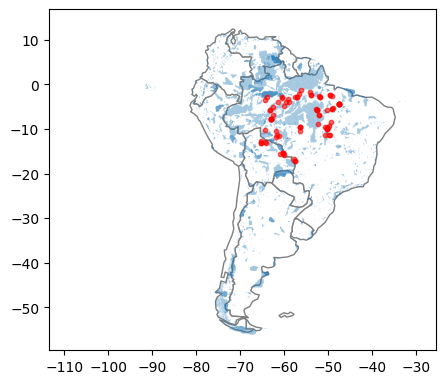

```python
ax = south_america.plot(figsize = (5, 5), color = 'white', edgecolor = 'gray')
protected_areas[protected_areas['MARINE'] != '2'].plot(ax = ax, alpha = 0.4, zorder = 1)
birds[birds['geometry'].y < 0].plot(ax = ax, color = 'red', alpha = 0.6, markersize = 10, zorder = 2)
```

# 그 다음은?

**[Lesson 3 : Interactive Maps](https://jw0112.github.io/blog/Data_Mining/Geospatial_Analysis/Geospatial_Analysis#lesson-3-interactive-maps)** 를 통해 지리공간 데이터로 대화형 지도를 만들어 보세요.

*Have questions or comments? Visit the [course discussion forum](https://www.kaggle.com/learn/geospatial-analysis/discussion) to chat with other learners.*